# Misterio en la Ciudad Imperial

Autores/as

Gema Fernández-Avilés (Gema.FAviles@uclm.es)

Isidro Hidalgo (Isidro.Hidalgo@uclm.es)

Fecha de publicación

20 de enero de 2025

# 1 Misterio en la Ciudad Imperial

Se sospecha que un individuo está traficando con libros fotocopiados en la ciudad de Toledo. Para determinar qué está pasando, se ha obtenido información de las antenas de telefonía a las que se ha conectado su teléfono móvil, así como los mensajes que ha enviado y recibido.

El caso es que el científico de datos de la Policía Local está recuperándose de una operación de hernia discal, y el Jefe de la Policía ha acudido a la UCLM para que los alumnos del curso “Storytelling visual con R” le solucionen la papeleta, ya que dice [sic] “que no hay nadie mejor que ellos para esto”.

# 2 Entender el contexto

**Cómo definir el propósito y la audiencia de tu análisis**

Aquí se trata de pillar al caco y obtener alguna evidencia de su delito. ¿Cómo lo podemos hacer? Con la información georreferenciada podemos ver por dónde ha estado. Con sus mensajes podemos ver quién se relaciona con él y montar alguna nube de palabras que lo delate… pues venga, sin más pérdida de tiempo… ¡A por él!

**Configuración inicial y datos**

```r
library(tidyverse)      # Para manipular los datos
library(leaflet)        # Para crear mapas interactivos
library(leaflet.extras) # Para crear extesiones en mapas interactivos
library(gstat)          # Para realizar interpolaciones espaciales
library(raster)         # Para trabajar con datos raster
library(igraph)         # Para trabajar con grafos
library(tm)             # Para trabajar con texto
library(wordcloud)      # Para crear nubes de palabras

antennas <- read_csv("data/book_antennas.csv")
connections <- read_csv("data/book_connections.csv")
messages <- read_csv("data/book_messages.csv")
```

# 3 Análisis exploratorio inicial

¿Qué tipo de datos tenemos? ¿Cómo son las variables?

**Código**

```r
head(antennas)
```

```
# A tibble: 6 × 4
  antenna_id latitude longitude intensity
       <dbl>    <dbl>     <dbl>     <dbl>
1          1     39.9     -4.03      56.9
2          2     39.9     -4.02      94.9
3          3     39.9     -4.03      90.5
4          4     39.9     -4.02      88.8
5          5     39.9     -4.03      63.9
6          6     39.9     -4.02      70.0
```

**Código**

```r
head(connections)
```

```
# A tibble: 6 × 6
  connection_id antenna_id latitude longitude intensity connection_time
          <dbl>      <dbl>    <dbl>     <dbl>     <dbl> <dttm>
1             1          2     39.9     -4.03      85.9 2023-01-01 00:00:00
2             2          9     39.9     -4.03      70.9 2023-01-01 01:00:00
3             3          9     39.9     -4.03      25.6 2023-01-01 02:00:00
4             4          9     39.9     -4.03      45.4 2023-01-01 03:00:00
5             5         10     39.9     -4.03      30.4 2023-01-01 04:00:00
6             6          2     39.9     -4.03      70.4 2023-01-01 05:00:00
```

**Código**

```r
head(messages)
```

```
# A tibble: 6 × 4
  message_id sender    receiver message
       <dbl> <chr>     <chr>    <chr>
1          1 Cox       Tukey    Hola, ¿tienes libros de Estadística disponibles?
2          2 Cox       Laplace  Sí, tengo varios. ¿Cuántos necesitas?
3          3 Pearson   Bayes    Necesito unos 10 libros. ¿Cuál es el precio?
4          4 Bayes     Wald     Te los dejo a buen precio. ¿Puedes recogerlos m…
5          5 Bernoulli Gibbs    Perfecto, nos vemos mañana.
6          6 Box       Neyman   ¿Tienes libros de Probabilidad en oferta?
```

## 3.1 Geolocalización de las antenas y las conexiones del movil objeto de interés

**Código**

```r
leaflet() |>
  addTiles() |>
  addCircleMarkers(data = antennas, ~longitude, ~latitude,
                   color = "red", radius = ~ intensity / 10,
                   label = ~ paste("Antena", antenna_id)) |>
  addCircleMarkers(data = connections, ~longitude, ~latitude,
                   color = "blue", radius = ~ intensity / 10,
                   label = ~ paste("Conexión", connection_id))
```

[interactive chart not shown]

Ay, qué papelón vamos a hacer… ¡Que el comercio se está produciendo en el entorno de la Facultad de Ciencias Jurídicas y Sociales!

## 3.2 Análisis espacial de la intensidad de las antenas. Localización y tipo de variable.

**Código**

```r
leaflet() |>
  addTiles() |>
  addCircleMarkers(data = antennas, ~longitude, ~latitude,
                   color = "red", radius = ~ intensity / 5,
                   label = ~ paste("Antena", antenna_id))
```

[interactive chart not shown]

Si hacemos un mapa de cobertura de las antenas, podemos hacer interpolación de su intensidad para representar la cobertura de cada una de ellas.

**mapa de cobertura de antenas**

```r
# Crear un objeto SpatialPointsDataFrame
coordinates(antennas) <- ~ longitude + latitude

# Definir la proyección (WGS84)
proj4string(antennas) <- CRS("+proj=longlat +datum=WGS84")

# Crear una cuadrícula para la interpolación
grd <- as.data.frame(spsample(antennas, "regular", n = 50000))
coordinates(grd) <- ~ x1 + x2 # (x + y)
gridded(grd) <- TRUE
proj4string(grd) <- proj4string(antennas)

# Realizar la interpolación IDW
idw <- idw(intensity ~ 1, antennas, grd)
```

```
[inverse distance weighted interpolation]
```

**mapa de cobertura de antenas**

```r
# Convertir el resultado a un objeto raster para la visualización
r <- raster(idw)

# Cargo los datos porque he sobreescrito el objeto antennas
antennas <- read_csv("data/book_antennas.csv")

# superponer la interpolación llamada r en el mapa leaflet
leaflet() |>
  addTiles() |>
  addRasterImage(r, colors = terrain.colors(10), opacity = 0.8) |>
  addCircleMarkers(data = antennas, ~longitude, ~latitude,
                   color = "red", radius = ~ intensity / 5,
                   label = ~ paste("Antena", antenna_id)) # |>
```

[interactive chart not shown]

# 4 ¿Con quién se relaciona el sospechoso? Los grafos

El Jefe de la Policía Local nos ha dicho que es conocido con el pseudónimo de **Laplace**. Si pudiéramos montar un grafo de relaciones quizá podríamos sacar alguna conclusión…

**grafo de relaciones entre actores**

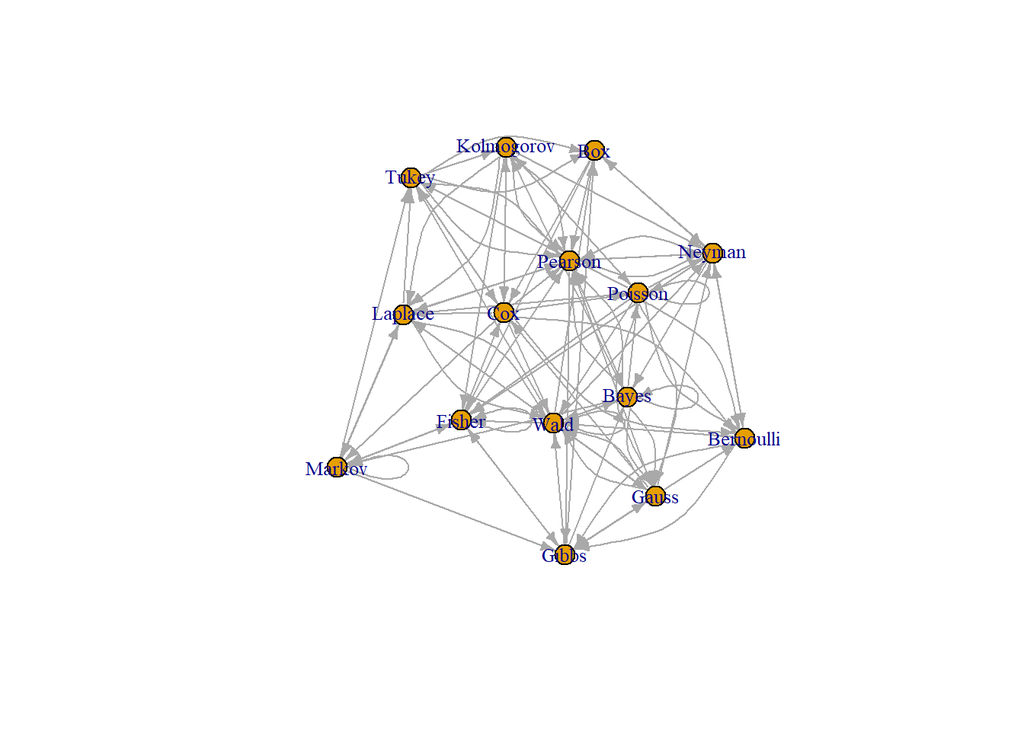

```r
graph_data <- messages |>
  dplyr::select(sender, receiver) |>
  graph_from_data_frame(directed = TRUE)

plot(graph_data,
     vertex.size = 10,
     vertex.label.cex = 0.8,
     edge.arrow.size = 0.5)
```

¿Y si mejoramos el grafo teniendo en cuenta la centralizada del nodo, es decir, la importancia de cada actor?

**grafo con la importancia de cada actor**

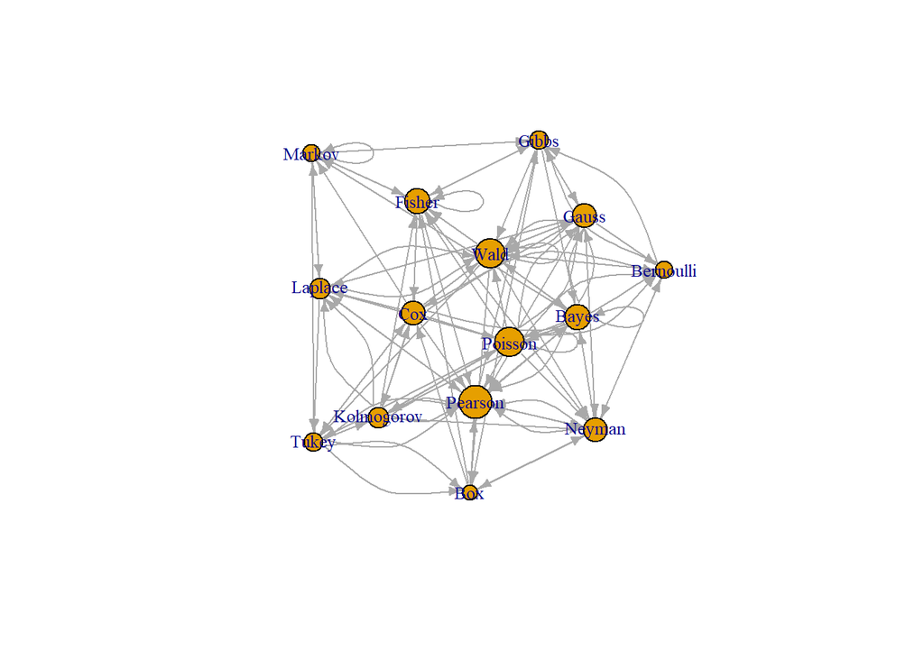

```r
plot(graph_data,
     vertex.size = degree(graph_data),
     vertex.label.cex = 0.8,
     edge.arrow.size = 0.5)
```

Pues cuidado, porque aquí hay una red entera de comercio de libros, por lo que el Jefe de Policía ya puede empezar a planificar un operativo bastante mayor del que probablemente pensaba hacer inicialmente. Si supiera Laplace que por su culpa se va a levantar una liebre tan grande, y van a pillar a muchos de sus colegas…